# Decision Trees

Jameson Watts, Ph.D.

03/07/2020

## 0.1 Agenda

1. Decision-trees
2. Weighted models for class imbalance
3. Random forests
4. Mid-term Review

# 1 Decision trees

## 1.1 (Long) Setup

```r
knitr::opts_chunk$set(echo = TRUE, message = FALSE, warning = FALSE)
library(tidyverse)
library(caret)
source('theme.R')

wine = as.data.frame(read_rds("../resources/pinot-project.rds")) %>%
  rowid_to_column("id") %>%
  mutate(lprice=log(price)) %>%

  select(-price)

#create a function to extract words with totals > j
wine_words <- function(data, j = 1000, stem=F){
  library(tidytext)
  library(SnowballC)
  data(stop_words)

  data <- data %>%
    unnest_tokens(word, description) %>%
    anti_join(stop_words) %>% # get rid of stop words
    filter(!(word %in% c("wine","pinot","vineyard")))

  if(stem){
    data <- data %>%
      mutate(word = wordStem(word))
  }

  data %>%
    count(id, word) %>%
    group_by(id) %>%
    mutate(exists = (n>0)) %>%
    ungroup %>%
    group_by(word) %>%
    mutate(total = sum(n)) %>%
    filter(total > j) %>%
    pivot_wider(id_cols = id, names_from = word, values_from = exists, values_fill = list(exists=0)) %>%
    right_join(select(wine,id, province, lprice, points)) %>%
    drop_na() %>%
    select(-id)
}

wino <- wine_words(wine, j=2000, stem=F) %>%
  filter(province %in% c("Oregon","California")) %>%
  head() %>%
  select(-lprice, -points) %>%
  arrange(province)

wino
```

| fruit | flavors | tannins | palate | black | cherry | red | province |
| --- | --- | --- | --- | --- | --- | --- | --- |
| FALSE | FALSE | FALSE | TRUE | FALSE | FALSE | FALSE | California |
| FALSE | TRUE | FALSE | FALSE | TRUE | TRUE | FALSE | California |
| TRUE | FALSE | FALSE | FALSE | FALSE | FALSE | FALSE | Oregon |
| FALSE | TRUE | TRUE | FALSE | FALSE | FALSE | FALSE | Oregon |
| FALSE | TRUE | FALSE | FALSE | FALSE | FALSE | FALSE | Oregon |
| TRUE | TRUE | TRUE | FALSE | FALSE | TRUE | FALSE | Oregon |

## 1.2 Algorithm

1. Select the best attribute -> A
2. Assign A as the decision attribute (test case) for the NODE.
3. For each value of A, create a new descendant of the NODE.
4. Sort the training examples to the appropriate descendant node leaf.
5. If examples are perfectly classified, then STOP else iterate over the new leaf nodes.

How do we find the best attribute?

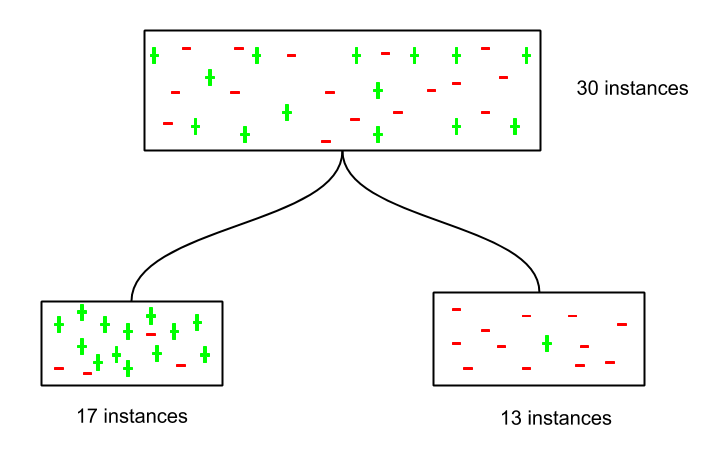

## 1.3 Information Gain

$InformationGain=Entropy(parent)-[AverageEntropy(children)]$

where,

$Entropy=\sum_{i=1}-(p_i)log(p_i)$

and $p$ is the proportion of the class under consideration.

## 1.4 Exercise

Let’s try splitting on “fruit” and see what we get.

$Entropy(fruit)=Entropy(2_o,0_c)+Entropy(2_o,2_c)$

$=-(2/2)log(2/2)-(0/2)log(0/2)-(2/4)log(2/4)-(2/4)log(2/4)=-0-0-0.35-0.35$

So the information gain is $0.63-0.35=0.28$

Is this better than splitting on tannins first?

## 1.5 Split the data

```r
wino <- wine_words(wine, j=2000, stem=F)
wine_index <- createDataPartition(wino$province, p = 0.80, list = FALSE)
train <- wino[ wine_index, ]
test <- wino[-wine_index, ]
table(train$province)
```

```
##
##          Burgundy        California Casablanca_Valley       Marlborough
##               916              2901               104               164
##          New_York            Oregon
##               103              2031
```

## 1.6 Fit a basic model

```r
library(rpart)
ctrl <- trainControl(method = "cv")

fit <- train(province ~ .,
             data = train,
             method = "rpart",
             trControl = ctrl,
             metric = "Kappa")

fit
```

```
## CART
##
## 6219 samples
##    9 predictor
##    6 classes: 'Burgundy', 'California', 'Casablanca_Valley', 'Marlborough', 'New_York', 'Oregon'
##
## No pre-processing
## Resampling: Cross-Validated (10 fold)
## Summary of sample sizes: 5598, 5596, 5598, 5597, 5598, 5596, ...
## Resampling results across tuning parameters:
##
##   cp          Accuracy   Kappa
##   0.02139843  0.6275790  0.3866629
##   0.02200121  0.6256482  0.3857861
##   0.09192285  0.5205400  0.1343389
##
## Kappa was used to select the optimal model using the largest value.
## The final value used for the model was cp = 0.02139843.
```

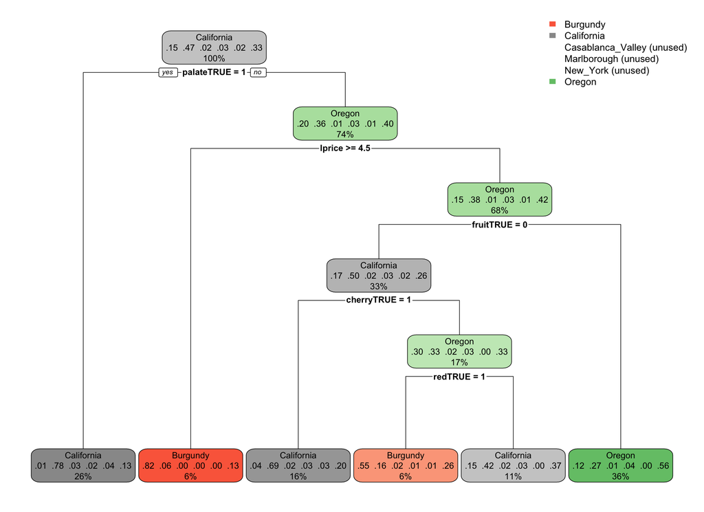

```r
library(rpart.plot)
rpart.plot(fit$finalModel, type = 2)
```

## 1.7 Confusion Matrix

```r
pred <- predict(fit, newdata=test)
confusionMatrix(factor(pred),factor(test$province))
```

```
## Confusion Matrix and Statistics
##
##                    Reference
## Prediction          Burgundy California Casablanca_Valley Marlborough
##   Burgundy               118         30                 2           2
##   California              47        561                20          18
##   Casablanca_Valley        0          0                 0           0
##   Marlborough              0          0                 0           0
##   New_York                 0          0                 0           0
##   Oregon                  63        134                 4          21
##                    Reference
## Prediction          New_York Oregon
##   Burgundy                 0     36
##   California              22    160
##   Casablanca_Valley        0      0
##   Marlborough              0      0
##   New_York                 0      0
##   Oregon                   3    311
##
## Overall Statistics
##
##                Accuracy : 0.6379
##                  95% CI : (0.6134, 0.6618)
##     No Information Rate : 0.4671
##     P-Value [Acc > NIR] : < 2.2e-16
##
##                   Kappa : 0.4161
##
##  Mcnemar's Test P-Value : NA
##
## Statistics by Class:
##
##                      Class: Burgundy Class: California
## Sensitivity                  0.51754            0.7738
## Specificity                  0.94713            0.6771
## Pos Pred Value               0.62766            0.6775
## Neg Pred Value               0.91935            0.7735
## Prevalence                   0.14691            0.4671
## Detection Rate               0.07603            0.3615
## Detection Prevalence         0.12113            0.5335
## Balanced Accuracy            0.73234            0.7255
##                      Class: Casablanca_Valley Class: Marlborough
## Sensitivity                           0.00000            0.00000
## Specificity                           1.00000            1.00000
## Pos Pred Value                            NaN                NaN
## Neg Pred Value                        0.98325            0.97358
## Prevalence                            0.01675            0.02642
## Detection Rate                        0.00000            0.00000
## Detection Prevalence                  0.00000            0.00000
## Balanced Accuracy                     0.50000            0.50000
##                      Class: New_York Class: Oregon
## Sensitivity                  0.00000        0.6134
## Specificity                  1.00000        0.7847
## Pos Pred Value                   NaN        0.5802
## Neg Pred Value               0.98389        0.8071
## Prevalence                   0.01611        0.3267
## Detection Rate               0.00000        0.2004
## Detection Prevalence         0.00000        0.3454
## Balanced Accuracy            0.50000        0.6991
```

Not bad… but what if we reduce the complexity constraint?

## 1.8 Lower complexity

$cp = \sum_{leaves} Misclass_i+\lambda(Splits)$

```r
fit <- train(province ~ .,
             data = train,
             method = "rpart",
             trControl = ctrl,
             tuneLength = 10,
             metric = "Kappa")

fit
```

```
## CART
##
## 6219 samples
##    9 predictor
##    6 classes: 'Burgundy', 'California', 'Casablanca_Valley', 'Marlborough', 'New_York', 'Oregon'
##
## No pre-processing
## Resampling: Cross-Validated (10 fold)
## Summary of sample sizes: 5596, 5597, 5598, 5599, 5595, 5597, ...
## Resampling results across tuning parameters:
##
##   cp           Accuracy   Kappa
##   0.002561784  0.6753349  0.4771592
##   0.002712477  0.6742082  0.4766458
##   0.002913402  0.6735646  0.4762954
##   0.003465943  0.6698710  0.4724111
##   0.005726341  0.6692289  0.4733895
##   0.018987342  0.6536452  0.4436740
##   0.019288728  0.6536452  0.4436740
##   0.021398433  0.6367463  0.4040653
##   0.022001206  0.6270919  0.3881628
##   0.091922845  0.5332622  0.1662859
##
## Kappa was used to select the optimal model using the largest value.
## The final value used for the model was cp = 0.002561784.
```

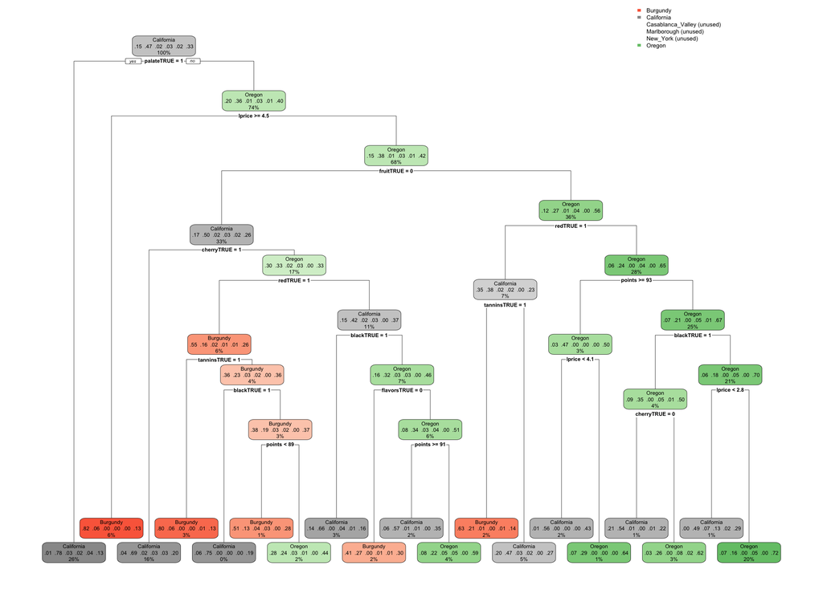

```r
rpart.plot(fit$finalModel, type = 2)
```

## 1.9 Potential Overfitting

Should I prune on…

- Depth?
- Class size?
- Complexity?
- Minimum Information Gain?

# 2 Weighted Models

```r
weight_train <- train %>%
  mutate(weights=if_else(province %in% c("Oregon","Burgundy","California"),1,10))


fit <- train(province ~ .,
             data = train,
             method = "rpart",
             weights = weight_train$weights,
             trControl = ctrl)

fit
```

```
## CART
##
## 6219 samples
##    9 predictor
##    6 classes: 'Burgundy', 'California', 'Casablanca_Valley', 'Marlborough', 'New_York', 'Oregon'
##
## No pre-processing
## Resampling: Cross-Validated (10 fold)
## Summary of sample sizes: 5596, 5599, 5597, 5598, 5597, 5597, ...
## Resampling results across tuning parameters:
##
##   cp          Accuracy   Kappa
##   0.02139843  0.5087607  0.30417060
##   0.02200121  0.5087607  0.30417060
##   0.09192285  0.3904183  0.06375629
##
## Accuracy was used to select the optimal model using the largest value.
## The final value used for the model was cp = 0.02200121.
```

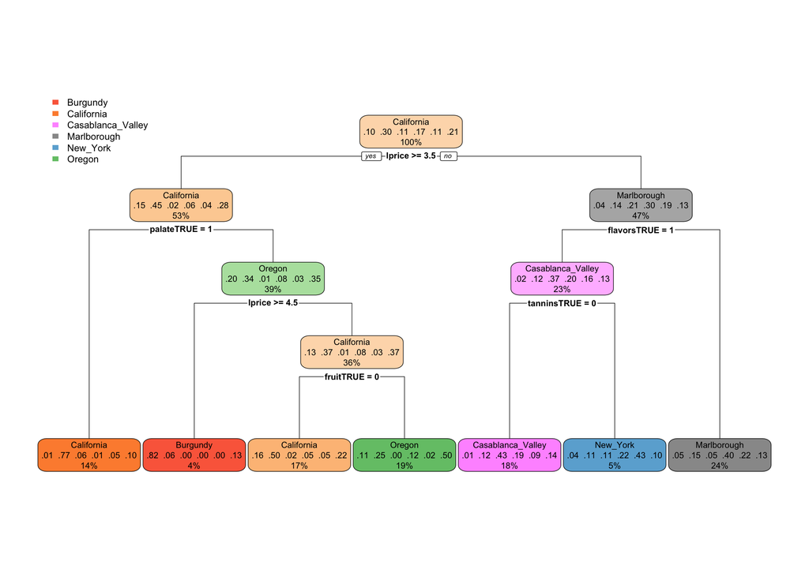

```r
rpart.plot(fit$finalModel, type = 2)
```

## 2.1 Confusion Matrix

```r
pred <- predict(fit, newdata=test)
confusionMatrix(factor(pred),factor(test$province))
```

```
## Confusion Matrix and Statistics
##
##                    Reference
## Prediction          Burgundy California Casablanca_Valley Marlborough
##   Burgundy                66          6                 0           0
##   California              77        450                 2           3
##   Casablanca_Valley        5         44                22           7
##   Marlborough             23        104                 1          27
##   New_York                 9         12                 0           0
##   Oregon                  48        109                 1           4
##                    Reference
## Prediction          New_York Oregon
##   Burgundy                 0     14
##   California               5    119
##   Casablanca_Valley        4     63
##   Marlborough              9     72
##   New_York                 7     10
##   Oregon                   0    229
##
## Overall Statistics
##
##                Accuracy : 0.5161
##                  95% CI : (0.4909, 0.5412)
##     No Information Rate : 0.4671
##     P-Value [Acc > NIR] : 6.242e-05
##
##                   Kappa : 0.3147
##
##  Mcnemar's Test P-Value : < 2.2e-16
##
## Statistics by Class:
##
##                      Class: Burgundy Class: California
## Sensitivity                  0.28947            0.6207
## Specificity                  0.98489            0.7509
## Pos Pred Value               0.76744            0.6860
## Neg Pred Value               0.88950            0.6931
## Prevalence                   0.14691            0.4671
## Detection Rate               0.04253            0.2899
## Detection Prevalence         0.05541            0.4227
## Balanced Accuracy            0.63718            0.6858
##                      Class: Casablanca_Valley Class: Marlborough
## Sensitivity                           0.84615            0.65854
## Specificity                           0.91940            0.86168
## Pos Pred Value                        0.15172            0.11441
## Neg Pred Value                        0.99716            0.98936
## Prevalence                            0.01675            0.02642
## Detection Rate                        0.01418            0.01740
## Detection Prevalence                  0.09343            0.15206
## Balanced Accuracy                     0.88278            0.76011
##                      Class: New_York Class: Oregon
## Sensitivity                  0.28000        0.4517
## Specificity                  0.97970        0.8450
## Pos Pred Value               0.18421        0.5857
## Neg Pred Value               0.98811        0.7606
## Prevalence                   0.01611        0.3267
## Detection Rate               0.00451        0.1476
## Detection Prevalence         0.02448        0.2519
## Balanced Accuracy            0.62985        0.6483
```

# 3 Random Forest

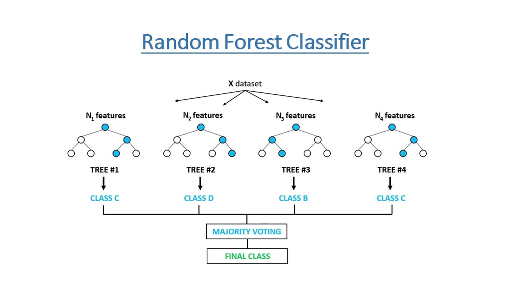

```r
library(randomForest)
fit <- train(province ~ .,
             data = train,
             method = "rf",
             weights = weight_train$weights,
             trControl = ctrl)

fit
```

```
## Random Forest
##
## 6219 samples
##    9 predictor
##    6 classes: 'Burgundy', 'California', 'Casablanca_Valley', 'Marlborough', 'New_York', 'Oregon'
##
## No pre-processing
## Resampling: Cross-Validated (10 fold)
## Summary of sample sizes: 5598, 5598, 5595, 5596, 5597, 5596, ...
## Resampling results across tuning parameters:
##
##   mtry  Accuracy   Kappa
##   2     0.6930321  0.5085516
##   5     0.7004402  0.5317878
##   9     0.6735830  0.4939173
##
## Accuracy was used to select the optimal model using the largest value.
## The final value used for the model was mtry = 5.
```

## 3.1 Confusion Matrix

```r
pred <- predict(fit, newdata=test)
confusionMatrix(factor(pred),factor(test$province))
```

```
## Confusion Matrix and Statistics
##
##                    Reference
## Prediction          Burgundy California Casablanca_Valley Marlborough
##   Burgundy               156         31                 0           4
##   California              33        590                12          13
##   Casablanca_Valley        2          3                 7           0
##   Marlborough              1          3                 2           6
##   New_York                 1          9                 1           0
##   Oregon                  35         89                 4          18
##                    Reference
## Prediction          New_York Oregon
##   Burgundy                 2     24
##   California              11    139
##   Casablanca_Valley        1      0
##   Marlborough              0      3
##   New_York                 8      2
##   Oregon                   3    339
##
## Overall Statistics
##
##                Accuracy : 0.7126
##                  95% CI : (0.6894, 0.735)
##     No Information Rate : 0.4671
##     P-Value [Acc > NIR] : < 2.2e-16
##
##                   Kappa : 0.5481
##
##  Mcnemar's Test P-Value : NA
##
## Statistics by Class:
##
##                      Class: Burgundy Class: California
## Sensitivity                   0.6842            0.8138
## Specificity                   0.9539            0.7485
## Pos Pred Value                0.7189            0.7393
## Neg Pred Value                0.9461            0.8210
## Prevalence                    0.1469            0.4671
## Detection Rate                0.1005            0.3802
## Detection Prevalence          0.1398            0.5142
## Balanced Accuracy             0.8191            0.7811
##                      Class: Casablanca_Valley Class: Marlborough
## Sensitivity                          0.269231           0.146341
## Specificity                          0.996068           0.994044
## Pos Pred Value                       0.538462           0.400000
## Neg Pred Value                       0.987654           0.977228
## Prevalence                           0.016753           0.026418
## Detection Rate                       0.004510           0.003866
## Detection Prevalence                 0.008376           0.009665
## Balanced Accuracy                    0.632649           0.570193
##                      Class: New_York Class: Oregon
## Sensitivity                 0.320000        0.6686
## Specificity                 0.991487        0.8574
## Pos Pred Value              0.380952        0.6947
## Neg Pred Value              0.988896        0.8421
## Prevalence                  0.016108        0.3267
## Detection Rate              0.005155        0.2184
## Detection Prevalence        0.013531        0.3144
## Balanced Accuracy           0.655743        0.7630
```

## 3.2 Summary

Pros

- Easy to use and understand.
- Can handle both categorical and numerical data.
- Resistant to outliers, hence require little data preprocessing.
- New features can be easily added.
- Can be used to build larger classifiers by using ensemble methods.

Cons

- Prone to overfitting.
- Require some kind of measurement as to how well they are doing.
- Need to be careful with parameter tuning.
- Can create biased learned trees if some classes dominate.

# 4 Mid-term Review

1. Multiple Regression
   - Model diagnostics
   - Variable interactions
   - RMSE
2. Data Ethics
   - Class imbalances
   - Anonymity and debiasing
3. Feature Engineering
   - Encoding categorical vairables
   - Interactions
   - Transformations
   - Standardizing
4. Resampling
   - Bootstrapping
   - V-fold Cross validations
5. Parameter Selection
   - Recursive feature elimination
6. KNN
   - How does it work?
   - Accuraccy vs. Kappa
   - Leakage
   - Tuning
   - Classification vs. Regression
   - Confusion Matrix
7. Naive Bayes
   - How does it work?
   - What is a conditional probability?
8. Tidytext
   - Document-term matrix
   - tokens, stems, bigrams
9. Logistic Regression
   - How does it work?
   - Why is it called regression and not classification?
   - ROC curves
   - Regularization
10. Decision Trees
    - How do they work?
    - What is information gain?
    - What is the complexity parameter?
    - What does weighting the classes accomlish?
    - How do random forests work?
    - What are the strengths / weaknesses?

# 5 References

http://www.learnbymarketing.com/tutorials/rpart-decision-trees-in-r/ https://www.hackerearth.com/practice/machine-learning/machine-learning-algorithms/ml-decision-tree/tutorial/